# Introducción a la EPH

Seminario Estadística y programación para estudios del trabajo, desigualdad y pobreza

DOCENTES:

Santiago Poy

Guido Weksler

[figure not shown]

# Conceptos Principales de EPH

## ¿Qué es la EPH?

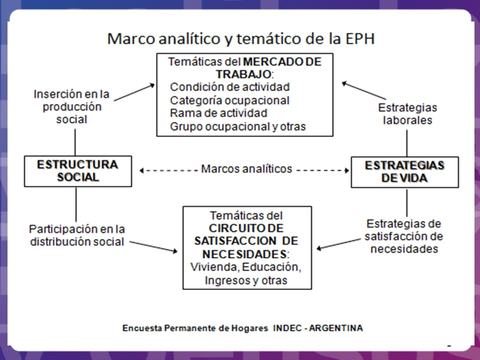

## Traduzcamos

### Objetivos de la EPH

**El objetivo general** de la encuesta es el conocimiento de un aspecto de nuestra realidad: La inserción de la población en la estructura económico-social<sup>1</sup>.

Dicha inserción puede ser analizada a partir de tres ejes:

1. Características demográficas.
2. Inserción en la producción de bienes y servicios.
3. Participación en la distribución del producto social.

## Características de la EPH

- **Orígen:** La encuesta nace en 1973 con la modalidad de relevamiento “*puntual*”: 2 ondas por año, en mayo y octubre.
- **Cambios:** En 2003 se lleva adelante la reformulación de la encuesta: pasa a ser un relevamiento contínuo y trimestral, relevandose 4 veces al año.
- **Esquema**: centralización normativa (equipo central) - descentralización ejecutvia (equipos provinciales).
- **Cobertura o dominio de estimación**: Principales aglomerados urbanos. Fue creciendo progresivamente desde la puntual hacia la continua, hasta llega a 31 aglomerados urbanos (todas las capitales de provincia + aquellos aglomerados con +100.000 habitantes).
- **Concepto de aglomerado**: *En las encuestas de fuerza de trabajo dos localidades distintas, pero próximas y que conforman en realidad un único mercado de trabajo, son tomadas como un único aglomerado.*<sup>2</sup>

- La encuesta representa al 72% del total urbano (En Arg. según el censo 2010 la población urbana llegaba al 90%)
- Que es el 62% del total pais
- Una vez al año se aplica al total urbano (EAHU).
- Proyecto en etapa de pruebas: cobertura del ámbito rural/urbano-rural (extensión al total país).

## La Muestra

- La Encuesta Permanente de Hogares es una encueta por muestreo: relevo a un “pequeño” puñado de hogares que representan al conjunto de la población.
  - Diseño Muestral: bietápica estratificada.
  - Tener en cuenta:
    - La representatividad
    - El margen de error
    - Coeficientes de variación de los estimadores
    - Límite superior/inferior de la estimación puntual
  - Esquema de rotación: 2-2-2 (la vivienda entra dos trimestres consecutivos - descansa dos trimestres consecutivos - vuelve a la muestra dos trimestres consecutivos)

### Principales temáticas abordadas por la EPH

- Características demográficas básicas
- Características ocupacionales
- Características migratorias
- Características habitacionales
- Características educacionales
- Características de ingreso

## Instrumento de medición: El medio hacia la operacionalización de los objetivos

- Operacionalizar: pasar de conceptos teóricos y abstractos a indicadores concretos y medibles.
- Recordar conceptos:
  - *Confiabilidad* (que el instrumento mida lo mismo sobre el mismo fenómeno a lo largo del tiempo)
  - *Validez* (¿medimos lo que decimos que queremos medir?)

## Tres cuestionarios

### Cuestionario de vivienda

- **Definición**: *“cualquier recinto fijo o móvil que ha sido construído o adaptado para alojar personas. Las viviendas pueden ser particulares o colectivas. La EPH sólo encuesta las particulares”.*
- Principales dimensiones que aborda el cuestionario de vivienda: * Identificación de viviendas y hogares * Características de la vivienda y hábitat * Condición de residencia

### Cuestionario de hogar

- **Definición**: *“Persona o grupo de personas parientes o no, que viven bajo un mismo techo y comparten los gastos de alimentación”*
- Principales dimensiones:

  ```
    + Características habitacionales
    + Caracetrísticas demográficas básicas (Sexo, edad, relación de parentesco)
    + Características educacionales (alfabetización, nivel educativo)
    + Condición de migración (país de nacimiento, de residencia en los últimos 5 años)
    + Cobertura de salud
    + División social del trabajo doméstico en el hogar
    + Presencia de discapacitados en el hogar
    + Estrategias y bases_eph de manutención de los hogares
    + Ingresos monetarios no laborales
  ```

#### El jefe o la jefa de hogar

**Definición:** *Aquella persona reconocida como tal por los demás miembros del hogar.* - **No es estático.** Responde tanto a un modelo general de asignación social y sexual de roles al interior del hogar como a criterios operativos:

```
+ económicos (quien trabaja / quien más cobra)
+ antigüedad
+ horarios (a quien se encuentra en el hogar)
```

- En caso de no haber acuerdo entre los miembros del hogar acerca de quién es el jefe o la jefa, se asigna por el o la encuestadora según los siguientes criterios (en orden de prioridad):

  ```
  1. Quien tiene a su cargo la responsabilidad económica del hogar
  1. El miembro más antiguo del hogar
  1. Quien haya acudido al llamado
  ```

## Marco analítico y temático de la EPH

### Cuestionario de individuos

- **Aplicación:** Todas aquellas personas residentes del hogar mayores de 10 años (niñosy niñas en edad escolar vs en edad de trabajar, en Argentina y otros países).
- **Respondentes** Mayor de 18 años (Puede ser auto o no auto-respondente)
- **Mide el principal concepto: El Trabajo**:
  - Definiión de la 19° Conferencia Internacional del Trabajo - OIT (CIET, 2013): Todas las actividades desarrolladas en unidades económicas por personas de cualquier sexo con el fin de producir bienes y servicios para el consumo de terceros o autoconsumo.
  - EPH: Es toda actividad destinada a la producción de bienes y servicios con valor económico en el mercado (trabajo en la ocupación)
- **La EPH toma una definición acotada del concepto de trabajo, acorde a sus objetivos y a sus instrumentos. No puede perder la capacidad de medir.**
- Entonces, ¿según la EPH, a quienes se los considera “trabajando”?
  - ¿Si realiza actividades laborales pagas en dinero o especie (en relación de dependencia, changas, trabajos temporarios, etc.)?

  SÍ
  - ¿Si rrealiza actividades para su propio consumo?

  NO
  - ¿Si realiza una contraprestación laboral en virtud de la recepción de un subsidio o plan social?

  SÍ
  - Si es trabajador o trabajadora por cuenta propia con instalaciones (taller, negocio u oficina) y concurrió a su lugar de trabajo aunque no tuvo clientes?

  SÍ
- ¿Si realiza actividades domésticas en su hogar (por ej. Ama de casa)?

  NO
- ¿Si realiza actividades voluntarias?

  NO
- ¿Si realiza actividades laborales no remuneradas (por ej. docentes ad-honorem, pasantes)?

  SÍ

## Cuestinario individual: Principales indicadores

- **Condición de actividad:** relación de las personas con la producción de bienes y servicios con valor económico en el mercado.
  - Categorías de la variable:
    - Ocupado u ocupada (quienes se encuentran trabajando en la semana de referencia o no trabajando pero manteniendo un puesto de trabajo -suspensiones-)
    - Desocupado o desocupada (quienes no tienen trabajo, están disponibles para trabajar y buscan trabajo activamente en algún momento de los últimos 30 días)
    - Inactivo o inactiva (quienes no se encuentran trabajando ni buscaron activamente trabajo en el período de referencia -últimos 30 días-)
- **Población económicamente activa:** Aquellas personas que tienen una ocupación o que sin tenerla la están buscando activamente (población ocupada + desocupada)

## Caracterización de la población ocupada

- **Pluriempleo**
- **Subocupación y sobreocupación -horaria-**
- **Demanda de empleo**
- **Categoría ocupacional:** En cuanto a la posición que tienen las personas respecto al esquema de relaciones sociales de producción, de un sistema de producción histórico y vigente (el capitalismo), los individuos se pueden clasificarse en:
  - Patrones
  - Cuenta propia
  - Asalariados
  - Trabajadores familiares

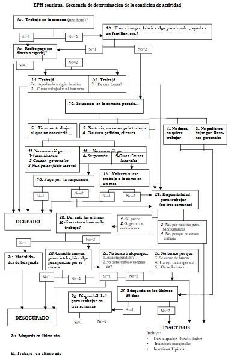

### Otros indicadores para describir a la población ocupada

- Intencidad en la inserción (subempleo)
- Búsqueda de otra ocupación (y sus causas)
- Tamaño del establecimiento
- Antigüedad en el puesto de trabajo / Continuidad laboral
- Calidad del empleo
- Utilización de capital (propio / ajeno)
- Movimientos interurbanos

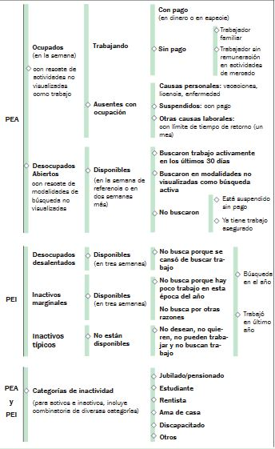

### Caracterízación de la población desocupada

- Tiempo de búsqueda
- Razones por las que no encuentra trabajo
- Temporalidad en la desocupación (nuevo desocupado / Viejo desocupado)
- Características de la última ocupación

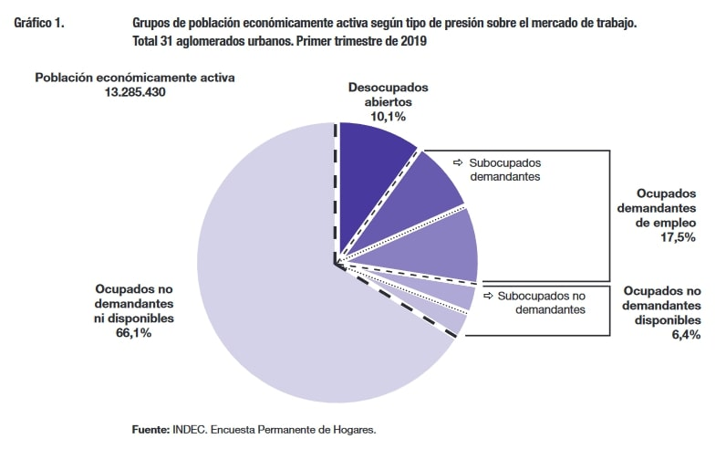

### Clasificadores utilizados en la EPH (Rama de actividad y Tarea / Ocupación)

- **Actividad (rama):** [Clasificador de Actividades para Encuestas Sociodemográficas (CAES-MERCOSUR)](https://www.indec.gob.ar/ftp/cuadros/menusuperior/clasificadores/notas_explicativas_caes_v2018.pdf)
- **Ocupación:** [Clasificador Nacional de Ocupaciones (CNO-2001-INDEC)](https://www.indec.gob.ar/ftp/cuadros/menusuperior/clasificadores/definiciones_conceptuales_cno.pdf)
- **Códigos geográficos:** [Países](https://www.indec.gob.ar/ftp/cuadros/menusuperior/eph/codigospaises_09.pdf) y [provincias](https://www.indec.gob.ar/ftp/cuadros/menusuperior/eph/codigosprovincias_09.pdf)

Acceso a materiales de la Encuesta:

- [Diseño de registro a agosto de 2019](https://www.indec.gob.ar/ftp/cuadros/menusuperior/eph/EPH_registro_1t19.pdf)
- [Cuestionario individual](https://www.indec.gob.ar/ftp/cuadros/sociedad/EPHContinua_CIndividual.pdf)
- [Cuestionario Hogar](https://www.indec.gob.ar/ftp/cuadros/sociedad/EPHContinua_CHogar.pdf)
- [Cuestionario vivienda](https://www.indec.gob.ar/ftp/cuadros/sociedad/EPHContinua_CVivienda.pdf)
- [La nueva EPH contínua](https://www.indec.gob.ar/ftp/cuadros/sociedad/metodologia_eph_continua.pdf)
- [Consideraciones sobre la revisión, evaluación y recuperación de la EPH. Nota metodológica actualizada para el uso de los datos del primer trimestre de 2019](https://www.indec.gob.ar/ftp/cuadros/menusuperior/eph/EPH_nota_metodologica_1_trim_2019.pdf)
- [Informe de mercado de trabajo a 1er trimestre de 2019](https://www.indec.gob.ar/uploads/informesdeprensa/mercado_trabajo_eph_1trim19B489ACCDF9.pdf)
- [Sistema de consulta a los cuadros regulares de la EPH contínua](https://www.indec.gob.ar/indec/web/Institucional-Indec-Fuentes_tabulado_continua)
- [Cartografía de la EPH](https://www.indec.gob.ar/indec/web/Nivel4-Tema-1-39-120)

## Ejercicios

- Identificar en los cuestionarios de vivienda, de hogar e individual las preguntas que dan cuenta de las áreas temáticas abordadas por la eph.
- Identificar, a su vez, qué preguntas dan cuenta de las temáticas del mercado de trabajo (tipo de inserción) y cuáles vinculadas al circuito de satisfacción de necesidades.

# Trabajando con las bases de microdatos

A lo largo de esta clase, trabajaremos procesando la Encuesta Permanente de Hogares con las distintas funciones del paquete [Tidyverse](https://www.tidyverse.org/). El mismo agrupa una serie de paquetes que tienen una misma lógica en su diseño y por ende funcionan en armonía.  
Entre ellos usaremos principalmente **dplyr** y **tidyr** para realizar transformaciones sobre nuestro set de datos, y **ggplot** para realizar gráficos (este último se verá en la clase 4).

## Importación de paquetes

A continuación cargamos **tidyverse** a nuestro ambiente. Para ello debe estar previamente instalado en nuestra PC. También utilizaremos los paquetes **openxlsx**, **eph** y **scales.**

```r
library(tidyverse)
library(openxlsx)
library(eph)
library(scales)
```

## Trabajar con encuestas de hogares

Algunas consideraciones al trabajar procesando microdatos provenientes de encuestas de hogares. Las encuestas se realizan sobre una muestra de hogares representativa de la población general y suelen ser llevadas a cabo por organismos oficiales de estadística. Dentro de las bases disponibles, suele haber una base de individual o de personas (donde cada fila del dataframe representa una persona del hogar), y también una base complementaria a nivel de los hogares. Gran parte del trabajo con los microdatos se realiza junto a un **Diseño de Registro**, que funciona como un ‘diccionario’ sobre las variables del dataframe. En dicho documento se indican las preguntas y respuestas relacionadas a cada variable y los valores que éstas toman. En la carpeta *bases_eph*, pueden encontrar el diseño de registro actual de la EPH (“EPH_registro_1T_2025.pdf”) así como también otros documentos metodológicos de la encuesta.

# Carga de Informacion

La función **list.files** nos permite observar los archivos que contiene una determinada carpeta

```r
list.files("../bases_eph/")
```

```
 [1] "Aglomerados y Regiones EPH.xlsx" "EPH_registro_1T2025.pdf"
 [3] "usu_hogar_T125.txt"              "usu_hogar_T225.txt"
 [5] "usu_hogar_T325.txt"              "usu_hogar_T424.txt"
 [7] "usu_individual_T125.txt"         "usu_individual_T225.txt"
 [9] "usu_individual_T325.txt"         "usu_individual_T424.txt"
```

La función **read.table** nos permite levantar los archivos de extensión “.txt”  
La función **read.xlsxl** del paquete openxlsx nos permite levantar los archivos de extensión “.xlsx”

Levantamos la base individual del primer trimestre de 2025, y un listado que contiene los Nombres y Códigos de los Aglomerados EPH.

```r
individual_25_t1 <-
  read.table("../bases_eph/usu_individual_T125.txt",
  sep = ";",
  dec = ",",
  header = TRUE,
  fill = TRUE )


Aglom <- openxlsx::read.xlsx("../bases_eph/Aglomerados y Regiones EPH.xlsx")
```

Para mostrar el funcionamiento básico de tidyverse, operaremos con la base Individual de la EPH (1er trimestre del año 2025) seleccionando únicamente una serie de variables de interés:

- código identificador del aglomerado (AGLOMERADO)
- identificador de aglomerados de más de 500.000 habitantes (MAS_500)
- sexo (CH04)
- edad (CH06)
- Ingreso total individual (P47T)
- Ponderador general (PONDERA),
- Ponderador para ingreso total individual (PONDII).

```r
Datos  <- individual_25_t1[c("AGLOMERADO","MAS_500","CH04","CH06","P47T","PONDERA","PONDII")]
```

# Medidas de resumen de las variables

Antes de comenzar a operar sobre la base de datos, veamos algunos comandos útiles para tener mayor noción sobre el tipo de información que vamos a trabajar.

### summary

Resume la información de cada una de las variables de la base de datos, mostrando distintos momentos de la distribución para variables *numéricas*, y un conteo de casos para variables del tipo *factor* o *character*

```r
summary(Datos)
```

```
   AGLOMERADO      MAS_500               CH04           CH06
 Min.   : 2.00   Length:45425       Min.   :1.00   Min.   : -1.00
 1st Qu.:10.00   Class :character   1st Qu.:1.00   1st Qu.: 18.00
 Median :22.00   Mode  :character   Median :2.00   Median : 35.00
 Mean   :23.08                      Mean   :1.52   Mean   : 36.79
 3rd Qu.:32.00                      3rd Qu.:2.00   3rd Qu.: 54.00
 Max.   :93.00                      Max.   :2.00   Max.   :103.00

      P47T             PONDERA           PONDII
 Min.   :      -9   Min.   :  21.0   Min.   :    0.0
 1st Qu.:       0   1st Qu.: 181.0   1st Qu.:  150.0
 Median :  128686   Median : 319.0   Median :  289.0
 Mean   :  409221   Mean   : 657.1   Mean   :  657.1
 3rd Qu.:  600000   3rd Qu.: 684.0   3rd Qu.:  655.0
 Max.   :25000000   Max.   :8257.0   Max.   :12055.0
 NA's   :75
```

**¿Qué les llama la atención del resumen de las variables de esta base?**

### unique

Permite ver los únicos valores que toma cierta variable en mi base de datos.

```r
unique(Datos$AGLOMERADO)
```

```
 [1]  4  8 27 19 31 13  9 38 12 33  2  7 91  6  3 36 15 26 23 32 34 22 10 93  5
[26] 30 29 20 25 18 14 17
```

### sample_n

Esta función está dentro del paquete tidyverse. Nos permite seleccionar de manera muy simple una muestra al azar de *n* casos de nuestra base de datos. Puede ser útil para una primera mirada de la base que trascienda a los primeros casos, o bien para procedimienos de muestreo aleatorio.

```r
sample_n(tbl = Datos,size = 9)
```

```
  AGLOMERADO MAS_500 CH04 CH06    P47T PONDERA PONDII
1         18       N    1   54  900000     403    400
2         13       S    2   41 1082000     538    566
3         10       S    2   58  400000     136    232
4         27       S    2   28  155000     381    389
5          5       S    1   40 1900000     776   1613
6         22       N    2   39  945000     166    178
7         19       N    1   51 1200000      76     76
8         30       N    1   43 1800000     321    337
9          7       N    1   21       0     392    392
```

### table

Esta función puede utilizarse para hacer tabulados univariados o bivariados en variables discretas.

```r
table(Datos$MAS_500,Datos$CH04)
```

```
        1     2
  N 11536 12424
  S 10280 11185
```

En este caso el resultado es un conteo *muestral* de los casos de varones (CH04 == 1) y mujeres (CH04 == 2) según sean de aglomerados de más de 500.000 habitantes (MAS_500 == “S”) o menos de 500.000 habitantes (MAS_500 == “N”).

### calculate_tabulates

En el *paquete eph* contamos con una función **calculate_tabulates()** que no sólo permite hacer un tabulado bivariado *ponderado*, sino que también tiene la opción de expresar directamente los tabulados en distribuciones porcentuales, agregar totales por filas y columnas, etiquetas, entre otras.

```r
eph::calculate_tabulates(base = Datos,x = "MAS_500",y = "CH04",weights = "PONDERA",add.totals = "both")
```

```
# A tibble: 3 × 4
  `MAS_500/CH04`      `1`      `2`    Total
  <chr>             <dbl>    <dbl>    <dbl>
1 N               2632343  2776154  5408497
2 S              11904280 12534401 24438681
3 Total          14536623 15310555 29847178
```

# Tidyverse

## Dplyr

El caracter principal para utilizar este paquete es `%>%` , *pipe* (de tubería).

El `%>%` toma el objeto que se especifique a su izquierda y lo ubica como primer argumento para realizar la operación que se indique a su derecha. Esto quiere decir que si comenzamos una sentencia con un dataFrame denominado **Datos** de la siguiente manera `Datos %>%` , no será necesario nombrar nuevamente al dataframe para referirse a una determinada variable/columna del mismo.

Veamos las principales funciones que pueden utilizarse con la lógica de este paquete:

### filter

Permite filtrar la tabla acorde al cumplimiento de condiciones lógicas

```r
pepito <- Datos %>%
  filter(CH04==1 , CH06>=50)
```

Nótese que en este caso al separar con una `,` las condiciones se exige el cumplimiento de ambas. En caso de desear que se cumpla al menos una condición debe utilizarse el caracter `|`

```r
Datos %>%
    filter(CH04==1| CH06>=50) %>%
    head(10) # Comando para que muestre los primeros 10 datos
```

```
   AGLOMERADO MAS_500 CH04 CH06   P47T PONDERA PONDII
1           4       S    1    4      0     927    927
2           4       S    1   -1      0     927    927
3           4       S    1    5      0    1294   1294
4           4       S    1   41 250000     727    960
5           4       S    2   51 699000     656    775
6           4       S    1   28     -9     656      0
7           4       S    1   24     -9     656      0
8           4       S    1   19      0     656    656
9           8       N    1   33 800000     472    766
10          8       N    1    6      0     472    472
```

> Ejercicio 1: Realicen un filtro que conserve a toda la población en edad jubilatoria (mujeres mayores a 60 años y varones mayores a 65)

### slice_max y slice_min

Permite conservar los **n** casos con los valores más altos o más bajos en una determinada variable.

```r
Datos %>%
  slice_max(order_by = P47T,n = 10)
```

```
   AGLOMERADO MAS_500 CH04 CH06     P47T PONDERA PONDII
1          31       N    1   64 25000000     148    172
2          91       N    1   61 25000000     202    209
3          30       N    1   38 21000000     294    306
4          33       S    2   24 20000000    3328   5196
5          30       N    2   50 16500000      47     45
6          33       S    1   40 16200000    1831   3477
7          32       S    1   45 15300000     536   1011
8          91       N    1   60 14000000     149    151
9          32       S    1   56 11000000     977   1289
10         33       S    1   31 10780000    1529   2394
```

### rename

Permite renombrar una columna de la tabla. Funciona de la siguiente manera: `Data %>% rename( nuevo_nombre = viejo_nombre )`

```r
Datos <- Datos %>%
  rename(EDAD = CH06)
Datos
```

```
      AGLOMERADO MAS_500 CH04 EDAD     P47T PONDERA PONDII
1              4       S    2   25   628000     927   1140
2              4       S    2    7        0     927    927
3              4       S    1    4        0     927    927
4              4       S    1   -1        0     927    927
5              4       S    2   29   690000    1294   1765
6              4       S    2   13        0    1294   1294
7              4       S    1    5        0    1294   1294
8              4       S    2   39   800000     727    894
9              4       S    1   41   250000     727    960
10             4       S    2    2        0     727    727
11             4       S    2   51   699000     656    775
12             4       S    1   28       -9     656      0
13             4       S    1   24       -9     656      0
14             4       S    1   19        0     656    656
```

[output cut: 14272 more lines]

Nótese que a diferencia del ejemplo de la función **filter** donde utilizábamos **==** para comprobar una condición lógica, en este caso se utiliza sólo un **=** ya que lo estamos haciendo es *asignar* un nombre.

### mutate

Permite agregar una variable a la tabla (especificando el nombre que tomará esta), que puede ser el resultado de operaciones sobre otras variables de la misma tabla.

Dentro del **mutate** cada `,` permitirá crear otra variable.

Tip: En caso de especificar el nombre de una columna existente, el resultado de la operación realizada “sobrescribirá” la información de la columna con dicho nombre

```r
Datos <- Datos %>%
  mutate(Edad_cuadrado=EDAD^2,
         Edad_cubo =EDAD^3)

Datos
```

```
      AGLOMERADO MAS_500 CH04 EDAD     P47T PONDERA PONDII Edad_cuadrado
1              4       S    2   25   628000     927   1140           625
2              4       S    2    7        0     927    927            49
3              4       S    1    4        0     927    927            16
4              4       S    1   -1        0     927    927             1
5              4       S    2   29   690000    1294   1765           841
6              4       S    2   13        0    1294   1294           169
7              4       S    1    5        0    1294   1294            25
8              4       S    2   39   800000     727    894          1521
9              4       S    1   41   250000     727    960          1681
10             4       S    2    2        0     727    727             4
11             4       S    2   51   699000     656    775          2601
12             4       S    1   28       -9     656      0           784
13             4       S    1   24       -9     656      0           576
14             4       S    1   19        0     656    656           361
```

[output cut: 22210 more lines]

### case_when

Permite definir una variable, la cual toma un valor particular para cada condición establecida. En caso de no cumplir ninguna de las condiciones establecidas la variable tomara valor **NA**.  
Su funcionamiento es el siguiente:  
`case_when(condicion1 ~ "Valor1",condicion2 ~ "Valor2",condicion3 ~ "Valor3")`

```r
Datos <- Datos %>%
  mutate(Grupos_Etarios = case_when(EDAD  < 18   ~ "Menores",
                                 EDAD  %in%  18:65   ~ "Adultos",
                                 EDAD  > 65 ~ "Adultos Mayores"))
Datos
```

```
     AGLOMERADO MAS_500 CH04 EDAD     P47T PONDERA PONDII Edad_cuadrado
1             4       S    2   25   628000     927   1140           625
2             4       S    2    7        0     927    927            49
3             4       S    1    4        0     927    927            16
4             4       S    1   -1        0     927    927             1
5             4       S    2   29   690000    1294   1765           841
6             4       S    2   13        0    1294   1294           169
7             4       S    1    5        0    1294   1294            25
8             4       S    2   39   800000     727    894          1521
9             4       S    1   41   250000     727    960          1681
10            4       S    2    2        0     727    727             4
11            4       S    2   51   699000     656    775          2601
12            4       S    1   28       -9     656      0           784
13            4       S    1   24       -9     656      0           576
14            4       S    1   19        0     656    656           361
```

[output cut: 19986 more lines]

> Ejercicio 2: Crear una variable nueva que distinga 4 categorías:  
> 1) Mujeres perceptoras de ingresos  
> 2) Varones perceptores de ingresos  
> 3) Mujeres no perceptoras de ingresos  
> 4) Varones no perceptores de ingresos  
> Pista, previamente estudiar los valores que puede tomar la variable P47T

### select

Permite especificar la serie de columnas que se desea conservar de un DataFrame. También pueden especificarse las columnas que se desean descartar (agregándoles un *-*). Muy útil para agilizar el trabajo en bases de datos de gran tamaño.

```r
#Conservo solo 2 variables
Datos %>%
  select(CH04,PONDERA)
```

```
      CH04 PONDERA
1        2     927
2        2     927
3        1     927
4        1     927
5        2    1294
6        2    1294
7        1    1294
8        2     727
9        1     727
10       2     727
11       2     656
12       1     656
13       1     656
14       1     656
```

[output cut: 45411 more lines]

```r
#Conservo todas las variables desde la 3era
Datos %>%
  select(3:ncol(.))
```

```
      CH04 EDAD     P47T PONDERA PONDII Edad_cuadrado Edad_cubo  Grupos_Etarios
1        2   25   628000     927   1140           625     15625         Adultos
2        2    7        0     927    927            49       343         Menores
3        1    4        0     927    927            16        64         Menores
4        1   -1        0     927    927             1        -1         Menores
5        2   29   690000    1294   1765           841     24389         Adultos
6        2   13        0    1294   1294           169      2197         Menores
7        1    5        0    1294   1294            25       125         Menores
8        2   39   800000     727    894          1521     59319         Adultos
9        1   41   250000     727    960          1681     68921         Adultos
10       2    2        0     727    727             4         8         Menores
11       2   51   699000     656    775          2601    132651         Adultos
12       1   28       -9     656      0           784     21952         Adultos
13       1   24       -9     656      0           576     13824         Adultos
14       1   19        0     656    656           361      6859         Adultos
```

[output cut: 12486 more lines]

### arrange

Permite ordenar la tabla por los valores de determinada/s variable/s. Es útil cuando luego deben hacerse otras operaciones que requieran del ordenamiento de la tabla

```r
Datos <- Datos %>%
  arrange(CH04,EDAD)
Datos
```

```
     AGLOMERADO MAS_500 CH04 EDAD    P47T PONDERA PONDII Edad_cuadrado
1             4       S    1   -1       0     927    927             1
2            27       S    1   -1       0     478    478             1
3            27       S    1   -1       0     319    319             1
4            10       S    1   -1       0     584    584             1
5             8       N    1   -1       0     123    123             1
6            10       S    1   -1       0     629    629             1
7            20       N    1   -1       0     273    273             1
8             6       N    1   -1       0     146    146             1
9            22       N    1   -1       0     146    146             1
10           14       N    1   -1       0     240    240             1
11           33       S    1   -1       0    2898   2898             1
12           36       N    1   -1       0     180    180             1
13           10       S    1   -1       0     547    547             1
14           33       S    1   -1       0    2457   2457             1
```

[output cut: 19986 more lines]

### summarise

Crea una nueva tabla que resume la información original. Para ello, definimos las variables de resumen y las formas de agregación. Calculemos por ejemplo la edad promedio de la población de nuestra base.

```r
#Recuerden que los menores de un año están clasificados con el valor -1
Datos <- Datos %>%
  mutate(edad.corregida=ifelse(EDAD == -1,yes = 0,no = EDAD))

#R BASE#
mean(Datos$edad.corregida,na.rm = T) #sin ponderar
```

```
[1] 36.7985
```

```r
weighted.mean(Datos$edad.corregida,Datos$PONDERA) #ponderado
```

```
[1] 35.25933
```

```r
#Tidyverse

Datos %>%
 summarise(Edad_prom = mean(edad.corregida),  #sin ponderar
           Edad_prom_pond = weighted.mean(x = edad.corregida,w = PONDERA)) #ponderado
```

```
  Edad_prom Edad_prom_pond
1   36.7985       35.25933
```

### group_by

Esta función permite realizar operaciones de forma agrupada. Lo que hace la función es “separar” a la tabla según los valores de la variable indicada y realizar las operaciones que se especifican a continuación, de manera independiente para cada una de las “subtablas”. En nuestro ejemplo, sería útil para calcular el promedio de edad según *sexo*

```r
Datos %>%
  group_by(CH04) %>%
  summarise(Edad_Prom = weighted.mean(EDAD,PONDERA))
```

```
# A tibble: 2 × 2
   CH04 Edad_Prom
  <int>     <dbl>
1     1      34.0
2     2      36.5
```

Notese que los `%>%` pueden usarse encadenados para realizar numerosos procedimientos sobre un dataframe original.Veamos un ejemplo con múltiples encadenamientos.

```r
Encadenado <- Datos %>%
  filter(Grupos_Etarios == "Adultos") %>%
  mutate(Sexo = case_when(CH04 == 1 ~ "Varon",
                          CH04 == 2 ~ "Mujer")) %>%
  select(-Edad_cuadrado)

Encadenado
```

```
     AGLOMERADO MAS_500 CH04 EDAD     P47T PONDERA PONDII Edad_cubo
1            27       S    1   18    28000     423    442      5832
2            31       N    1   18        0     263    263      5832
3            27       S    1   18        0     315    315      5832
4            27       S    1   18       -9     315      0      5832
5            27       S    1   18        0     292    292      5832
6            32       S    1   18   300000     672    886      5832
7             8       N    1   18        0     159    159      5832
8            20       N    1   18        0     126    126      5832
9            18       N    1   18        0      67     67      5832
10            6       N    1   18        0     139    139      5832
11           38       N    1   18        0     108    108      5832
12            6       N    1   18        0     158    158      5832
13           33       S    1   18    85000    2450   4336      5832
14           14       N    1   18        0      88     88      5832
```

[output cut: 18168 more lines]

> Ejercicio 3: Calculen el ingreso individual promedio y luego el ingreso promedio para varones y mujeres. Consideren para el calculo sólo los casos de quienes perciben ingresos (no tomen los valores 0)

## Joins

Otra implementación muy importante del paquete dplyr son las funciones para unir tablas (joins)

### left_join

Veamos un ejemplo de la función **left_join** (una de las más utilizadas en la práctica).  
Para ello utilizaremos el Dataframe *Aglom* con los códigos y los nombres de los aglomerados EPH

```r
Aglom
```

```
   AGLOMERADO                          Nom_Aglo
1          32                   Ciudad de Bs As
2          33                  Partidos del GBA
3          10                      Gran Mendoza
4          27                     Gran San Juan
5          26           San Luis - El Chorrillo
6          12                        Corrientes
7          15                           Formosa
8           8                  Gran Resistencia
9           7                           Posadas
10         22                    Gran Catamarca
11          2                     Gran La Plata
12          3              Bahía Blanca - Cerri
13          4                      Gran Rosario
14          5                     Gran Santa Fé
```

[output cut: 18 more lines]

```r
Datos_join <- Datos %>%
  left_join(.,Aglom, by = "AGLOMERADO")

Datos_join
```

```
     AGLOMERADO MAS_500 CH04 EDAD    P47T PONDERA PONDII Edad_cuadrado
1             4       S    1   -1       0     927    927             1
2            27       S    1   -1       0     478    478             1
3            27       S    1   -1       0     319    319             1
4            10       S    1   -1       0     584    584             1
5             8       N    1   -1       0     123    123             1
6            10       S    1   -1       0     629    629             1
7            20       N    1   -1       0     273    273             1
8             6       N    1   -1       0     146    146             1
9            22       N    1   -1       0     146    146             1
10           14       N    1   -1       0     240    240             1
11           33       S    1   -1       0    2898   2898             1
12           36       N    1   -1       0     180    180             1
13           10       S    1   -1       0     547    547             1
14           33       S    1   -1       0    2457   2457             1
```

[output cut: 16654 more lines]

```r
Poblacion_Aglomerados <- Datos_join %>%
  group_by(Nom_Aglo) %>%
  summarise(Menores = sum(PONDERA[Grupos_Etarios=="Menores"]),
            Adultos = sum(PONDERA[Grupos_Etarios=="Adultos"]),
            Adultos_Mayores = sum(PONDERA[Grupos_Etarios=="Adultos Mayores"]))

Poblacion_Aglomerados
```

```
# A tibble: 32 × 4
   Nom_Aglo                     Menores Adultos Adultos_Mayores
   <chr>                          <int>   <int>           <int>
 1 " Bahía Blanca - Cerri"        66851  207513           47913
 2 " Cdro. Rivadavia - R.Tilly"   78831  157091           21321
 3 " Ciudad de Bs As"            693137 1834884          477611
 4 " Concordia"                   48978  100999           15936
 5 " Corrientes"                 105264  249024           39074
 6 " Formosa"                     74689  165291           24724
 7 " Gran Catamarca"              64953  147307           21720
 8 " Gran Córdoba"               429169 1002744          174894
 9 " Gran La Plata"              248272  585789          105958
10 " Gran Mendoza"               283803  647459          130240
# ℹ 22 more rows
```

## Tidyr

El paquete tidyr esta pensado para facilitar el emprolijamiento de los datos. Veremos las funciones *pivot_longer* y *pivot_wider* que nos permitirán pivotear la base según como queramos ordenar los datos para trabajarlos posteriormente o bien para presentarlos como tabla de resultados.

[figure not shown]

fuente: https://bookdown.org/Maxine/r4ds/pivoting.html

### pivot_longer

Nos permite pivotear los datos en columnas hacia una única variable. El *“longer”* refiere a que ahora nuestro dataframe va a tener más filas (y menos columnas)

```r
pob.aglo.long <- Poblacion_Aglomerados %>%
  pivot_longer(cols = 2:4,names_to = "Grupo_Etario",values_to = "Poblacion")

pob.aglo.long
```

```
# A tibble: 96 × 3
   Nom_Aglo                     Grupo_Etario    Poblacion
   <chr>                        <chr>               <int>
 1 " Bahía Blanca - Cerri"      Menores             66851
 2 " Bahía Blanca - Cerri"      Adultos            207513
 3 " Bahía Blanca - Cerri"      Adultos_Mayores     47913
 4 " Cdro. Rivadavia - R.Tilly" Menores             78831
 5 " Cdro. Rivadavia - R.Tilly" Adultos            157091
 6 " Cdro. Rivadavia - R.Tilly" Adultos_Mayores     21321
 7 " Ciudad de Bs As"           Menores            693137
 8 " Ciudad de Bs As"           Adultos           1834884
 9 " Ciudad de Bs As"           Adultos_Mayores    477611
10 " Concordia"                 Menores             48978
# ℹ 86 more rows
```

### pivot_wider

Es el opuesto de **pivot_longer**. Nos permite pivotear los datos de una variable para obtener múltiples columnas en función de alguna variable categórica que clasifique a la anterior. El “wider” refiere a que ahora nuestro dataframe va a tener menos filas (y más columnas, en función de la cantidad de categorías de la variable que use para pivotear)

```r
pob.aglo.long %>%
  pivot_wider(names_from = "Grupo_Etario",values_from = "Poblacion")
```

```
# A tibble: 32 × 4
   Nom_Aglo                     Menores Adultos Adultos_Mayores
   <chr>                          <int>   <int>           <int>
 1 " Bahía Blanca - Cerri"        66851  207513           47913
 2 " Cdro. Rivadavia - R.Tilly"   78831  157091           21321
 3 " Ciudad de Bs As"            693137 1834884          477611
 4 " Concordia"                   48978  100999           15936
 5 " Corrientes"                 105264  249024           39074
 6 " Formosa"                     74689  165291           24724
 7 " Gran Catamarca"              64953  147307           21720
 8 " Gran Córdoba"               429169 1002744          174894
 9 " Gran La Plata"              248272  585789          105958
10 " Gran Mendoza"               283803  647459          130240
# ℹ 22 more rows
```

# Tasas del Mercado de Trabajo

- Tasa de empleo: $\frac{Ocupados}{Población}$

## Tasa de Empleo agregada

Creamos una tabla con los niveles de:

- Población
- Ocupados

```r
Poblacion_ocupados <- individual_25_t1 %>%
  summarise(Poblacion         = sum(PONDERA),
            Ocupados          = sum(PONDERA[ESTADO == 1]))

Poblacion_ocupados
```

```
  Poblacion Ocupados
1  29847178 13258809
```

- Población: Si contaramos cuantos registros tiene la base, simplemente tendríamos el numero de individuos muestral de la EPH, por ende debemos **sumar los valores de la variable PONDERA**, para contemplar a cuantas personas representa cada individuo encuestado.
- Ocupados: En este caso, debemos agregar un **filtro** al procedimiento anterior, ya que unicamente queremos sumar los ponderadores de aquellas personas que se encuentran ocupadas. (La lógica seria: “Suma los valores de la columna PONDERA, solo para aquellos registros donde el ESTADO == 1”)

La función `summarise()` nos permite crear multiples variables de resumen al mismo tiempo, simplemente separando con una `,` cada uno de ellas. A su vez, se pueden crear variables, a partir de las variables creadas por la propia función. De esta forma, podemos, directamente calcular la **tasa de empleo** a partir del total poblacional y de ocupados.

```r
Empleo <- individual_25_t1 %>%
  summarise(Poblacion         = sum(PONDERA),
            Ocupados          = sum(PONDERA[ESTADO == 1]),
            Tasa_Empleo    = Ocupados/Poblacion)

Empleo
```

```
  Poblacion Ocupados Tasa_Empleo
1  29847178 13258809   0.4442232
```

En caso de querer expresar los resultados como porcentajes, podemos utilizar la función **percent** del paquete *scales*. Para ello debemos utilizar **mutate** para transformar la variable `Tasa_Empleo`

Nótese que en este caso, para poder añadir el %, la función transforma a la variable en un Character, por ende debe tenerse en cuenta que se pierde la información del numero completo. Esto es simplemente una herramienta para visualizar la información final en terminos de %, no utilizarla si se va a seguir operando con dicho valor.

```r
Empleo %>%
  mutate(Tasa_Empleo_Porc = scales::percent(Tasa_Empleo))
```

```
  Poblacion Ocupados Tasa_Empleo Tasa_Empleo_Porc
1  29847178 13258809   0.4442232              44%
```

## Tasa de Empleo por aglomerado

Replicando el procedimiento anterior, pero añadiendo previamente un `group_by()`, podemos realizar la misma estimación, pero desagregada por alguna variable de interés (por ejemplo, por aglomerado)

```r
Empleo_aglo <- individual_25_t1 %>%
  group_by(AGLOMERADO)%>%
  summarise(Poblacion         = sum(PONDERA),
            Ocupados          = sum(PONDERA[ESTADO == 1]),
            Tasa_Empleo    = Ocupados/Poblacion)
```

# Exportar resultados a Excel

La función **write.xlsx** de la libreria [openxlsx](https://ycphs.github.io/openxlsx/) nos permite exportar un dataframe a un archivo de Excel. Hay una infinidad de formas para hacer la exportación, agregando títulos a los cuadros, múltiples dataframes en una misma solapa del excel, o creando múltiples solapas en el excel. Todas estas variantes, con ejemplos, se pueden consultar [acá](https://ycphs.github.io/openxlsx/articles/Introduction.html).

La forma más simple, sólo requiere indicar el dataframe a exportar, y la ruta completa, con extensión del archivo incluido

```r
dir.create("Resultados")
openxlsx::write.xlsx(x = Empleo,file =  "Resultados/miexportacion.xlsx")
```

Si queremos exportar más de un objeto, cada uno a una pestaña distinta, lo que tenemos que pasar en el parámetro `x` es una lista de objetos.

```r
dir.create("Resultados")
openxlsx::write.xlsx(
  x = list(Empleo,Empleo_aglo),
  file =  "Resultados/miexportacion_2.xlsx")
```

## Referencias

R Core Team. (2024). *R: A Language and Environment for Statistical Computing*. R Foundation for Statistical Computing, Vienna, Austria. Recuperado de https://www.R-project.org/

Posit Team. (2025). *RStudio IDE User Guide*. Posit Software, PBC. Recuperado de https://docs.posit.co/ide/user/

CEPED. (2022). Ceped.data. Portal de difusión de datos del Centro de Estudios sobre Población, Empleo y Desarrollo (CEPED-UBA), Universidad de Buenos Aires, Buenos Aires. Recuperado de https://ceped-data.shinyapps.io/ceped-data/

Observatorio de Empleo y Dinámica Empresarial (OEDE). (2025). Estadísticas e indicadores nacionales de OEDE. Ministerio de Capital Humano, Argentina. Recuperado de https://www.argentina.gob.ar/trabajo/estadisticas/oede-estadisticas-nacionales

[Seminario "Estadística y programación para estudios del trabajo, desigualdad y pobreza". Doctorado en Ciencias Sociales](https://www.sociales.uba.ar/posgrados/doctorado/)

*guidowe45@gmail.com*